# Introducción a la inferencia

AE

26/7/2017

## Intervalos de confianza

Hemos estado trabajando con estimaciones puntuales

¡Recuerda, poner el directorio!

```r
setwd("/Users/anaescoto/Dropbox/DGAPA/EjercicioR")
install.packages("foreign", repos = "http://cran.us.r-project.org", dependencies = TRUE)
library(foreign)
```

La base que usamos es la modificada de la práctica anterior. Que se puede descargar de [aquí](https://www.dropbox.com/s/9giicw5ffqnguss/enigh_concentrado_mod.dbf?dl=0)

```r
enigh_concentrado <- read.dbf("enigh_concentrado_mod.dbf")
```

# t-test

Este comando nos sirve para calcular diferentes tipos de test, que tienen como base la distribución t

**Univariado para estimación**

```r
t.test(enigh_concentrado$ing_cor)
```

```
##
##  One Sample t-test
##
## data:  enigh_concentrado$ing_cor
## t = 100.02, df = 19478, p-value < 2.2e-16
## alternative hypothesis: true mean is not equal to 0
## 95 percent confidence interval:
##  36532.62 37993.07
## sample estimates:
## mean of x
##  37262.84
```

**Univariado para hipótesis específica**

Supongamos que queremos saber si ingreso corriente per cápita es superior la canasta básica urbana trimestral (7766.2949)

```r
#Cálculo ingresos percápita
enigh_concentrado$ing_pc<-enigh_concentrado$ing_cor/enigh_concentrado$tot_integ

t.test(enigh_concentrado$ing_pc, mu=7766.2949)
```

```
##
##  One Sample t-test
##
## data:  enigh_concentrado$ing_pc
## t = 32.585, df = 19478, p-value < 2.2e-16
## alternative hypothesis: true mean is not equal to 7766.295
## 95 percent confidence interval:
##  12010.46 12553.73
## sample estimates:
## mean of x
##   12282.1
```

# prop.test

```r
freq.sex<-table(enigh_concentrado$sexo_jefe)
prop.table(freq.sex)
```

```
##
##    Hombre     Mujer
## 0.7453155 0.2546845
```

```r
freq.sex
```

```
##
## Hombre  Mujer
##  14518   4961
```

```r
prop.test(freq.sex)
```

```
##
##  1-sample proportions test with continuity correction
##
## data:  freq.sex, null probability 0.5
## X-squared = 4688, df = 1, p-value < 2.2e-16
## alternative hypothesis: true p is not equal to 0.5
## 95 percent confidence interval:
##  0.7391233 0.7514105
## sample estimates:
##         p
## 0.7453155
```

Por default, toma los valores de la primera categoría, también podemos hacer la estimación con los datos del total de “éxitos” y el total de “intentos”. Calculemos para las mujeres jefas

```r
prop.test(4961,19479)
```

```
##
##  1-sample proportions test with continuity correction
##
## data:  4961 out of 19479, null probability 0.5
## X-squared = 4688, df = 1, p-value < 2.2e-16
## alternative hypothesis: true p is not equal to 0.5
## 95 percent confidence interval:
##  0.2485895 0.2608767
## sample estimates:
##         p
## 0.2546845
```

Para hacer la prueba con respecto a un nivel de proporción.

```r
prop.test(4961,19479, alternative = "greater", p=0.25)
```

```
##
##  1-sample proportions test with continuity correction
##
## data:  4961 out of 19479, null probability 0.25
## X-squared = 2.2549, df = 1, p-value = 0.0666
## alternative hypothesis: true p is greater than 0.25
## 95 percent confidence interval:
##  0.2495586 1.0000000
## sample estimates:
##         p
## 0.2546845
```

# Estimaciones bivariadas

## Diferencias de medias por grupos

```r
tapply(enigh_concentrado$ing_pc,enigh_concentrado$sexo_jefe, mean)
```

```
##   Hombre    Mujer
## 12052.12 12955.11
```

```r
t.test(enigh_concentrado$ing_pc~enigh_concentrado$sexo_jefe)
```

```
##
##  Welch Two Sample t-test
##
## data:  enigh_concentrado$ing_pc by enigh_concentrado$sexo_jefe
## t = -2.8408, df = 8593.9, p-value = 0.004511
## alternative hypothesis: true difference in means is not equal to 0
## 95 percent confidence interval:
##  -1526.0858  -279.8874
## sample estimates:
## mean in group Hombre  mean in group Mujer
##             12052.12             12955.11
```

Gráficamente lo podemos ver en un “boxplot”

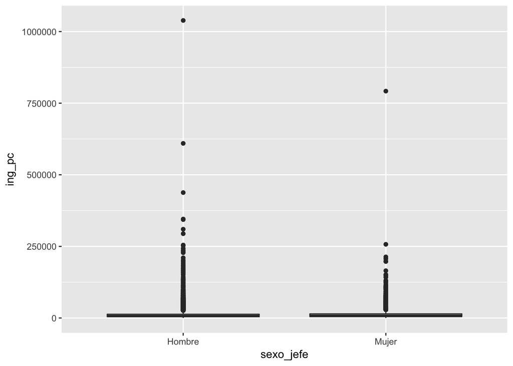

```r
install.packages("ggplot2", repos = "http://cran.us.r-project.org", dependencies = TRUE)
library(ggplot2)
qplot(sexo_jefe, ing_pc, data = enigh_concentrado, geom = "boxplot")
```

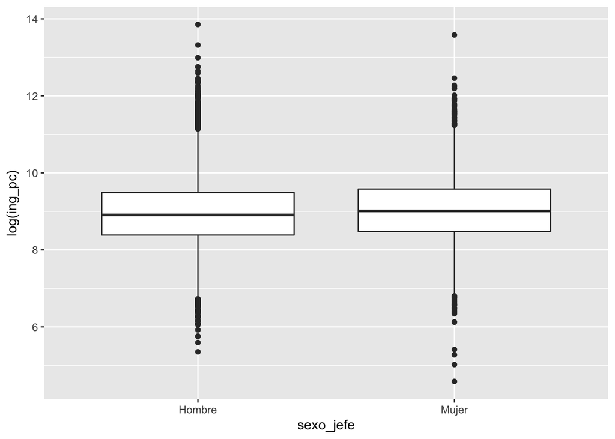

```r
qplot(sexo_jefe, log(ing_pc), data = enigh_concentrado, geom = "boxplot")
```

Gráficando esos grupos

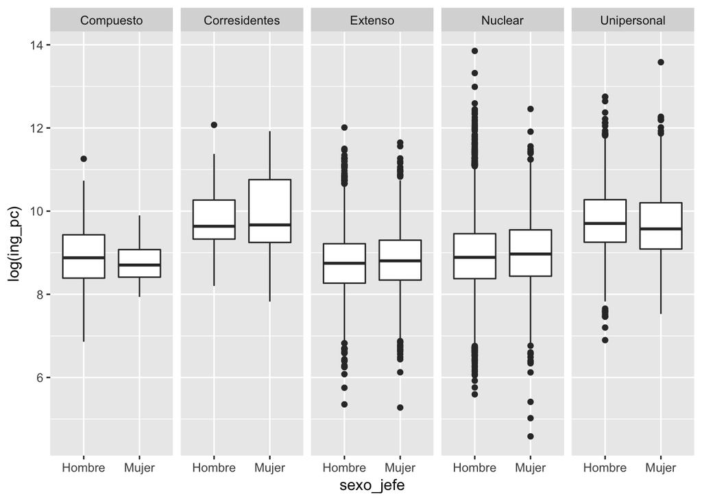

```r
qplot(sexo_jefe, log(ing_pc), data = enigh_concentrado, geom = "boxplot") + facet_grid(. ~clase_hog)
```

# Prueba chi-cuadradro chi-sq

```r
table(enigh_concentrado$clase_hog, enigh_concentrado$sexo_jefe)
```

```
##
##                 Hombre Mujer
##   Compuesto         87    42
##   Corresidentes     50    27
##   Extenso         2995  1697
##   Nuclear        10318  2314
##   Unipersonal     1068   881
```

```r
chisq.test(enigh_concentrado$clase_hog, enigh_concentrado$sexo_jefe)
```

```
##
##  Pearson's Chi-squared test
##
## data:  enigh_concentrado$clase_hog and enigh_concentrado$sexo_jefe
## X-squared = 1030.2, df = 4, p-value < 2.2e-16
```

# Correlación

Mide la fuerza de la relación lineal ¡Ojo con lineal!

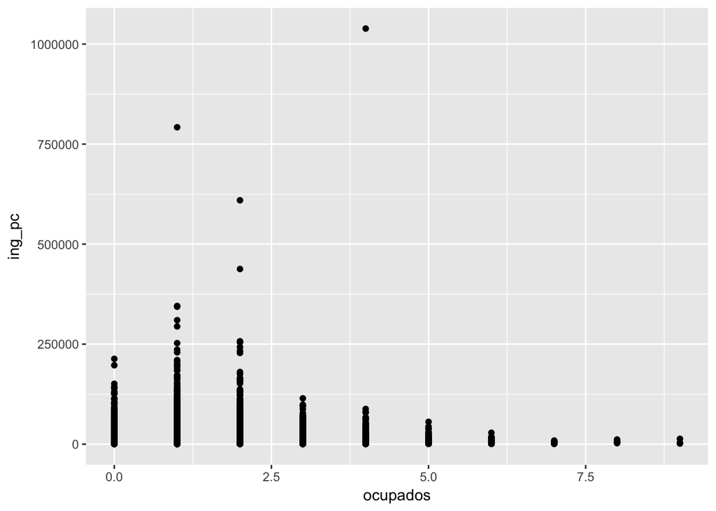

```r
qplot(y=ing_pc, x=ocupados, data=enigh_concentrado)
```

```r
cor(enigh_concentrado$ing_pc, enigh_concentrado$ocupados)
```

```
## [1] -0.06202266
```

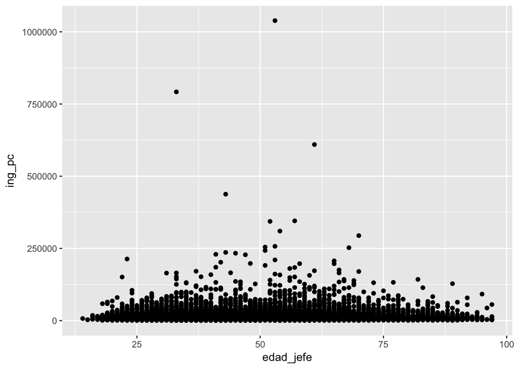

```r
qplot(y=ing_pc, x=edad_jefe, data=enigh_concentrado)
```

```r
cor(enigh_concentrado$ing_pc, enigh_concentrado$edad_jefe)
```

```
## [1] 0.04345169
```

# Regresión lineal

**Regresión lineal simple**

La regresión lineal nos ayuda a describir esta relación a través de una línea recta.

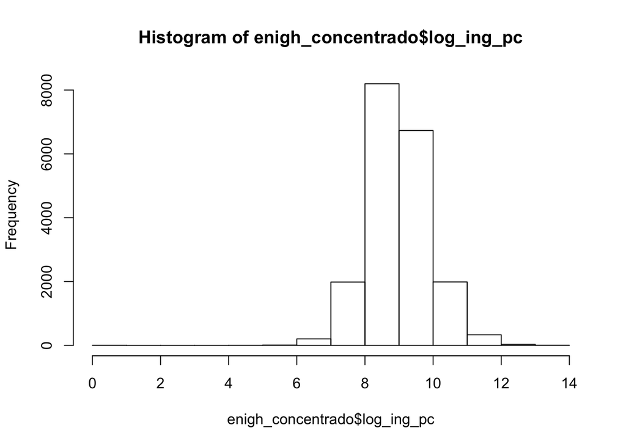

```r
enigh_concentrado$log_ing_pc<-log(enigh_concentrado$ing_pc+1)
hist(enigh_concentrado$log_ing_pc)
```

Una vez transformada nuestra variable, corremos el modelo

```r
modelo <-lm(log_ing_pc ~  ocupados, data=enigh_concentrado, na.action=na.fail)
summary(modelo) # show results
```

```
##
## Call:
## lm(formula = log_ing_pc ~ ocupados, data = enigh_concentrado,
##     na.action = na.fail)
##
## Residuals:
##     Min      1Q  Median      3Q     Max
## -9.0775 -0.5791 -0.0424  0.5295  5.0028
##
## Coefficients:
##              Estimate Std. Error t value Pr(>|t|)
## (Intercept)  9.077533   0.011669 777.935   <2e-16 ***
## ocupados    -0.056676   0.005897  -9.611   <2e-16 ***
## ---
## Signif. codes:  0 '***' 0.001 '**' 0.01 '*' 0.05 '.' 0.1 ' ' 1
##
## Residual standard error: 0.8789 on 19477 degrees of freedom
## Multiple R-squared:  0.00472,    Adjusted R-squared:  0.004669
## F-statistic: 92.37 on 1 and 19477 DF,  p-value: < 2.2e-16
```

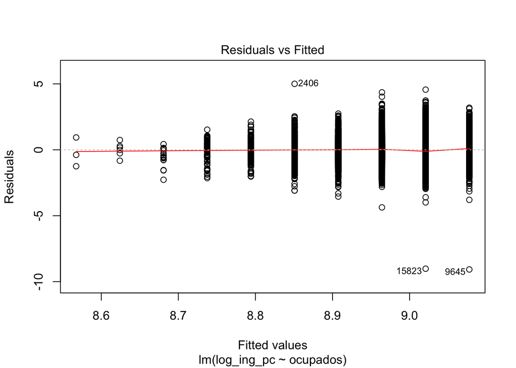

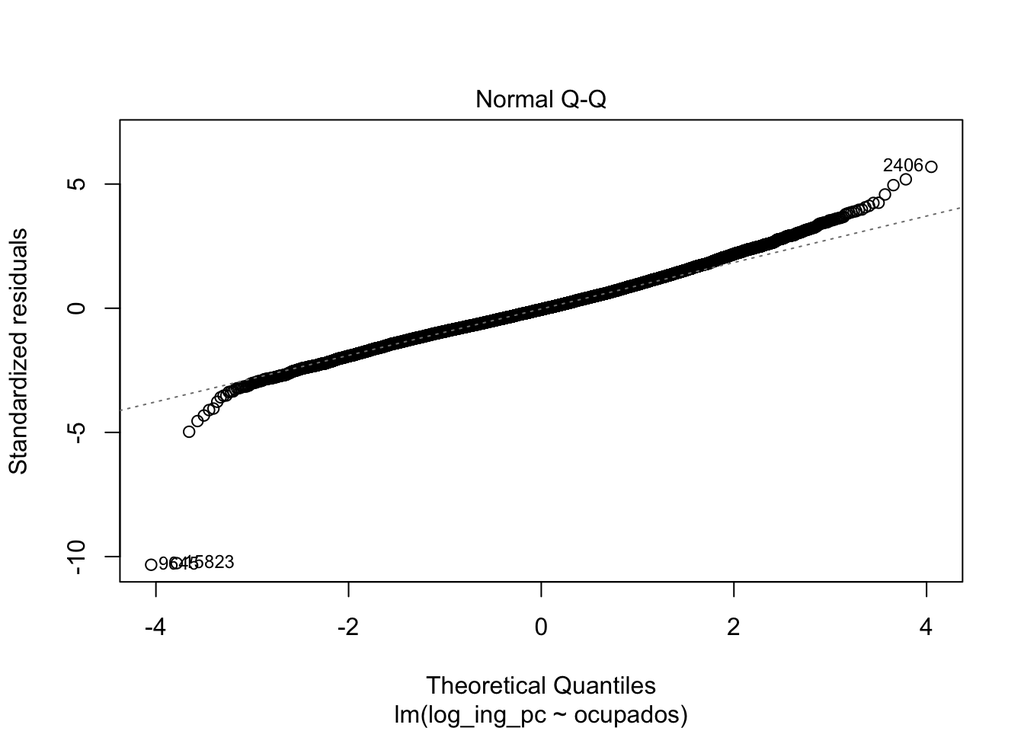

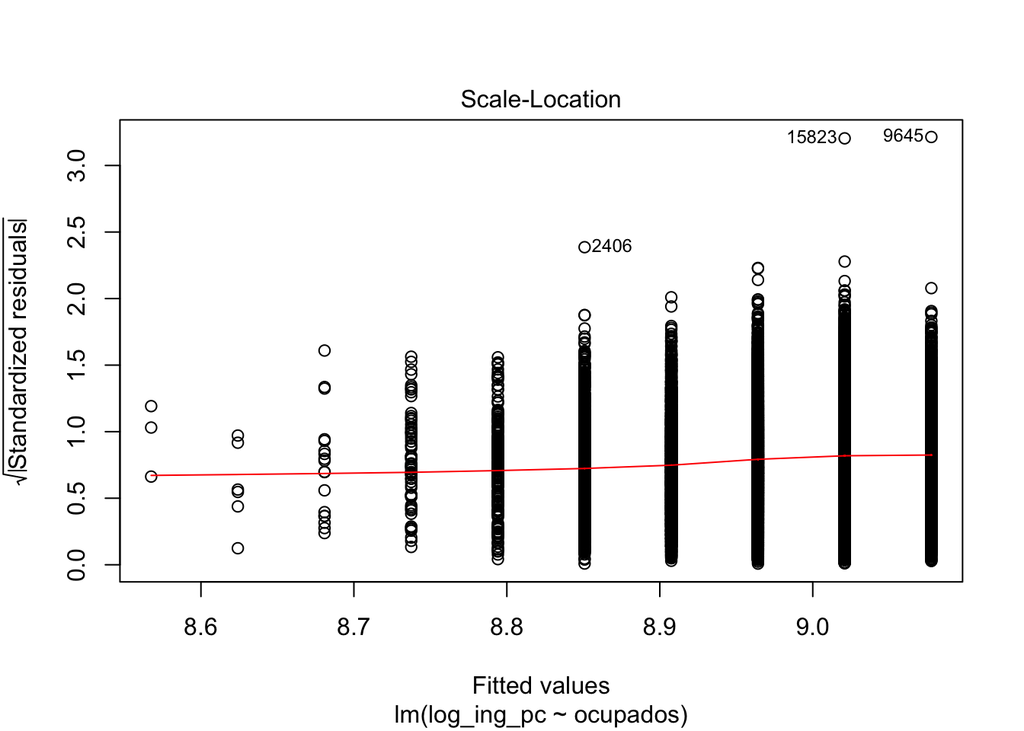

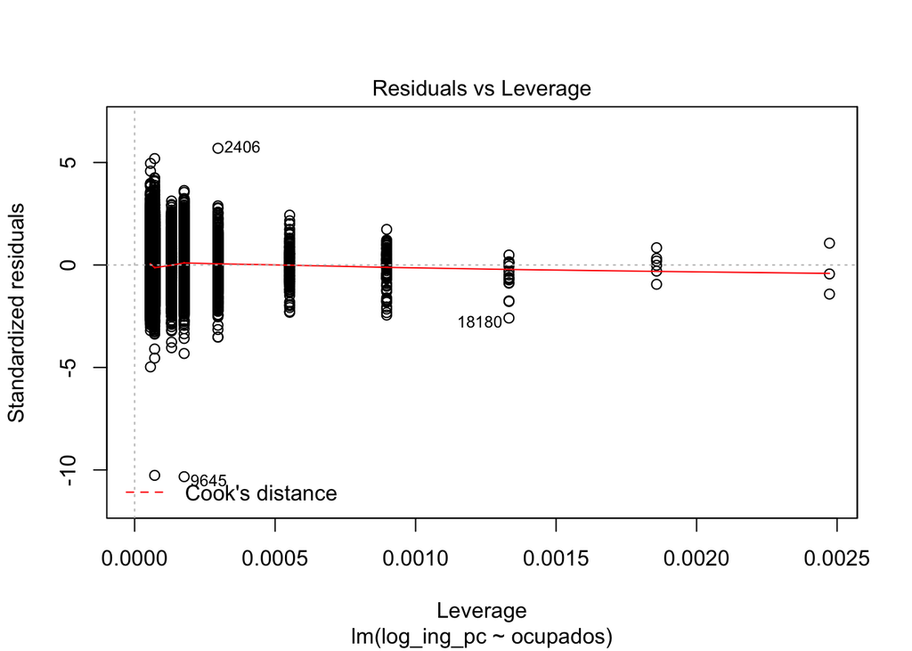

```r
plot(modelo)
```